# Project: An investigation into an Appontment dataset

- Introduction
- Data Wrangling
- Data Cleaning
- Exploratory Data Analysis
- Conclusions

## Introduction

For this project I have chosen to look at an appointment dataset. This data was provided as part of the Udacity Data Analysis Nanodegree and was originally found at [Kaggle](https://www.kaggle.com/joniarroba/noshowappointments).

*Question*:

What factors have the biggest impact on whether a patient will show up for their appointment?

## General Properties

Get things setup to work with the data

```python
import pandas as pd
import numpy as np
% matplotlib inline

import matplotlib.pyplot as plt
import seaborn as sns
sns.set_style('whitegrid')
# Stop floats from displaying as scientific notation because this is annoying
pd.options.display.float_format = '{:20,.2f}'.format
```

Importing the data to look it over.

```python
# Load data and print out a few lines. Perform operations to inspect data
# types and look for instances of missing or possibly errant data.
appts = pd.read_csv('noshowappts.csv')
```

#### High level view of the dataset

In this section I'll take an initial view of the data - this will also include the number of rows, the datatypes and the number of non-null values in those columns. I'll also take a look at the number of unique values for those columns.

```python
# a quick overview of the data
appts.head(6)
```

|  | PatientId | AppointmentID | Gender | ScheduledDay | AppointmentDay | Age | Neighbourhood | Scholarship | Hipertension | Diabetes | Alcoholism | Handcap | SMS_received | No-show |
| --- | --- | --- | --- | --- | --- | --- | --- | --- | --- | --- | --- | --- | --- | --- |
| 0 | 29,872,499,824,296.00 | 5642903 | F | 2016-04-29T18:38:08Z | 2016-04-29T00:00:00Z | 62 | JARDIM DA PENHA | 0 | 1 | 0 | 0 | 0 | 0 | No |
| 1 | 558,997,776,694,438.00 | 5642503 | M | 2016-04-29T16:08:27Z | 2016-04-29T00:00:00Z | 56 | JARDIM DA PENHA | 0 | 0 | 0 | 0 | 0 | 0 | No |
| 2 | 4,262,962,299,951.00 | 5642549 | F | 2016-04-29T16:19:04Z | 2016-04-29T00:00:00Z | 62 | MATA DA PRAIA | 0 | 0 | 0 | 0 | 0 | 0 | No |
| 3 | 867,951,213,174.00 | 5642828 | F | 2016-04-29T17:29:31Z | 2016-04-29T00:00:00Z | 8 | PONTAL DE CAMBURI | 0 | 0 | 0 | 0 | 0 | 0 | No |
| 4 | 8,841,186,448,183.00 | 5642494 | F | 2016-04-29T16:07:23Z | 2016-04-29T00:00:00Z | 56 | JARDIM DA PENHA | 0 | 1 | 1 | 0 | 0 | 0 | No |
| 5 | 95,985,133,231,274.00 | 5626772 | F | 2016-04-27T08:36:51Z | 2016-04-29T00:00:00Z | 76 | REPÚBLICA | 0 | 1 | 0 | 0 | 0 | 0 | No |

Now to take a look at the number of rows and columns I will be starting with.

```python
appts.shape
```

```
(110527, 14)
```

## Data Wrangling

Now to begin getting the data into a useful fashion.

Change the data type for some items to more logiccally be bool type.

```python
appts[['Scholarship','Hipertension','Diabetes','Alcoholism','Handcap','SMS_received']] = appts[['Scholarship','Hipertension','Diabetes','Alcoholism','Handcap','SMS_received']].astype('bool')
```

Going to change the datatypes for the dates and times for scheduled and actual appointments.

```python
appts['ScheduledDay'] = pd.to_datetime(appts['ScheduledDay']) #this line converts the ScheduledDay to a datetime type
appts['AppointmentDay'] = pd.to_datetime(appts['AppointmentDay']) #same as above, just for the appointment day
```

Taking a quick look for NaN data or other oddities that might need to be wrangled.

```python
# gathering more info
appts.info()
```

```
<class 'pandas.core.frame.DataFrame'>
RangeIndex: 110527 entries, 0 to 110526
Data columns (total 14 columns):
PatientId         110527 non-null float64
AppointmentID     110527 non-null int64
Gender            110527 non-null object
ScheduledDay      110527 non-null datetime64[ns, UTC]
AppointmentDay    110527 non-null datetime64[ns, UTC]
Age               110527 non-null int64
Neighbourhood     110527 non-null object
Scholarship       110527 non-null bool
Hipertension      110527 non-null bool
Diabetes          110527 non-null bool
Alcoholism        110527 non-null bool
Handcap           110527 non-null bool
SMS_received      110527 non-null bool
No-show           110527 non-null object
dtypes: bool(6), datetime64[ns, UTC](2), float64(1), int64(2), object(3)
memory usage: 7.4+ MB
```

Looking over the returned data from running the .info method, we can see that there are no NaN entries in the data which makes the process more straight forward. We can see this by checking the 'RangeIndex' number returned at the top of the information returned and comparing that the the number of non-null entries show per column in the rest of the information. To double confirm this, will run a .isnull method as well.

```python
appts.isnull().sum().sum()
#this will add up the total NaN entries for the whole dataframe by adding up the sum of each column
```

```
0
```

Now that the NaN value checking process is complete, and finding that no missing values are present, we move onto the next step of data cleaning.

### Data Cleaning

This is the process of looking for any data that is out of the domain, or not supportive of finding answers to the posed. questions

```python
# gathering more info about the dataframe
appts.describe()
```

|  | PatientId | AppointmentID | Age |
| --- | --- | --- | --- |
| count | 110,527.00 | 110,527.00 | 110,527.00 |
| mean | 147,496,265,710,392.38 | 5,675,305.12 | 37.09 |
| std | 256,094,920,291,738.88 | 71,295.75 | 23.11 |
| min | 39,217.84 | 5,030,230.00 | -1.00 |
| 25% | 4,172,614,444,192.00 | 5,640,285.50 | 18.00 |
| 50% | 31,731,838,713,978.00 | 5,680,573.00 | 37.00 |
| 75% | 94,391,720,898,175.00 | 5,725,523.50 | 55.00 |
| max | 999,981,631,772,427.00 | 5,790,484.00 | 115.00 |

Taking a look at the info gathered from using the describe meathod relveales a couple of oddities that look like they will need to be addressed. The min for Age is -1, which will not make sense. Also the max Age is 115 which also seems unusual. So some extra data cleaning of these outliers will need to be done.

```python
appts['Age'].value_counts()
# this will get the value counts of each age item.
```

```
 0      3539
 1      2273
 52     1746
 49     1652
 53     1651
 56     1635
 38     1629
 59     1624
 2      1618
 50     1613
 57     1603
 36     1580
 51     1567
 19     1545
 39     1536
```

[output cut: 47 more lines]

Now looking at the output data from the value_counts method, even though Age 0 was looking a bit odd, it occurse frequently. This is likely not a mistake then, and reflects an unborn child by my logic. The other Ages that cause me to ponder are the ages over 100. However, there are multiple entries for that age range, so it does not seem to be misentered data. I will check those entries to see if they are all the same patient at each age in a moment. The age of -1 will need to be checked, as there is only the single entry which suggests it might have been a misentry of the data.

```python
x = -1 # variable to hold the age I am checking in
print 'this is for Age', x,'\n\n', appts.loc[appts['Age'] == x]['PatientId'].value_counts()
#this line of code checks for how many unique occurences of
# each patient ID for a specific age. I use this to investigate any odd ages that showed up in the above code.
```

```
this is for Age -1

465,943,158,731,293.00    1
Name: PatientId, dtype: int64
```

Now to check age 99, then 115, 102 and finally 100

```python
x = 99 # variable to hold the age I am checking in
print 'this is for Age', x,'\n\n', appts.loc[appts['Age'] == x]['PatientId'].value_counts()
#this line of code checks for how many unique occurences of
# each patient ID for a specific age. I use this to investigate any odd ages that showed up in the above code.
```

```
this is for Age 99

36,615,771,819.00    1
Name: PatientId, dtype: int64
```

```python
x = 115 # variable to hold the age I am checking in
print 'this is for Age', x,'\n\n', appts.loc[appts['Age'] == x]['PatientId'].value_counts()
#this line of code checks for how many unique occurences of
# each patient ID for a specific age. I use this to investigate any odd ages that showed up in the above code.
```

```
this is for Age 115

31,963,211,613,981.00     4
748,234,579,244,724.00    1
Name: PatientId, dtype: int64
```

```python
x = 102 # variable to hold the age I am checking in
print 'this is for Age', x,'\n\n', appts.loc[appts['Age'] == x]['PatientId'].value_counts()
#this line of code checks for how many unique occurences of
# each patient ID for a specific age. I use this to investigate any odd ages that showed up in the above code.
```

```
this is for Age 102

976,294,799,775,439.00    1
  234,283,596,548.00      1
Name: PatientId, dtype: int64
```

```python
x = 100 # variable to hold the age I am checking in
print 'this is for Age', x,'\n\n', appts.loc[appts['Age'] == x]['PatientId'].value_counts()
#this line of code checks for how many unique occurences of
# each patient ID for a specific age. I use this to investigate any odd ages that showed up in the above code.
```

```
this is for Age 100

9,739,429,797,896.00     2
55,783,129,426,615.00    1
  393,964,189,799.00     1
Name: PatientId, dtype: int64
```

After running the last few checks, I find that the data should be good in its quality other than the Age being reported as -1. I will drop that data from the dataset as part of the cleaning process.

```python
print appts.shape
appts = appts.drop(appts.loc[appts['Age'] == -1]['PatientId'].index) #this overwrites the original dataframe with the new one
#that has dropped the bad data
print appts.shape
```

```
(110527, 14)
(110526, 14)
```

Having the shape of the dataframe before the drop and after the drop to confirm.

```python
x = -1 # variable to hold the age I am checking in
print 'this is for Age', x,'\n\n', appts.loc[appts['Age'] == x]['PatientId'].value_counts()
#this line of code checks for how many unique occurences of
# each patient ID for a specific age. I use this to investigate any odd ages that showed up in the above code.
```

```
this is for Age -1

Series([], Name: PatientId, dtype: int64)
```

Having the bad data looked up same way as before to confirm that it was indeed dropped correctly.

A view of the number of unique values in the columns:

```python
appts.nunique()
```

```
PatientId          62298
AppointmentID     110526
Gender                 2
ScheduledDay      103548
AppointmentDay        27
Age                  103
Neighbourhood         81
Scholarship            2
Hipertension           2
Diabetes               2
Alcoholism             2
Handcap                2
SMS_received           2
No-show                2
dtype: int64
```

#### Confirm ambiguous datatypes

Checking that everything is the correct data type for my needs.

```python
print"I am PatientId: ", type(appts['PatientId'][0])
print"I am AppointmentID: ", type(appts['AppointmentID'][0])
print"I am Gender: ", type(appts['Gender'][0])
print"I am ScheduledDay: ", type(appts['ScheduledDay'][0])
print"I am AppointmentDay: ", type(appts['AppointmentDay'][0])
print"I am Age: ", type(appts['Age'][0])
print"I am Neighbourhood: ", type(appts['Neighbourhood'][0])
print"I am Scholarship: ", type(appts['Scholarship'][0])
print"I am Hipertension: ", type(appts['Hipertension'][0])
print"I am Diabetes: ", type(appts['Diabetes'][0])
print"I am Alcoholism: ", type(appts['Alcoholism'][0])
print"I am Handcap : ", type(appts['Handcap'][0])
print"I am SMS_received: ", type(appts['SMS_received'][0])
print"I am No-show: ", type(appts['No-show'][0])
```

```
I am PatientId:  <type 'numpy.float64'>
I am AppointmentID:  <type 'numpy.int64'>
I am Gender:  <type 'str'>
I am ScheduledDay:  <class 'pandas._libs.tslibs.timestamps.Timestamp'>
I am AppointmentDay:  <class 'pandas._libs.tslibs.timestamps.Timestamp'>
I am Age:  <type 'numpy.int64'>
I am Neighbourhood:  <type 'str'>
I am Scholarship:  <type 'numpy.bool_'>
I am Hipertension:  <type 'numpy.bool_'>
I am Diabetes:  <type 'numpy.bool_'>
I am Alcoholism:  <type 'numpy.bool_'>
I am Handcap :  <type 'numpy.bool_'>
I am SMS_received:  <type 'numpy.bool_'>
I am No-show:  <type 'str'>
```

High level overview of the amount of rows and columns.

```python
appts.shape #checking the shape again to confirm
```

```
(110526, 14)
```

Dropping a few columns as they are not relavant to the questions posed here as well as removing rows that did not show.

I will drop the AppointmentID, ScheduledDay, and AppointmentDay. And clean the data into whether the patient showed up or not.

```python
appts_that_showed = appts.copy() #create a copy of the data to look at it and drop uneeded catigories
did_not_show_up_appts = appts.copy() #second copy that I will be testing
appts_that_showed.drop(['AppointmentID', 'ScheduledDay', 'AppointmentDay'], axis=1, inplace=True)
did_not_show_up_appts.drop(['AppointmentID', 'ScheduledDay', 'AppointmentDay'], axis=1, inplace=True)
appts_that_showed.drop(appts[appts['No-show'] == 'No'].index, inplace = True) #removing the no-show rows so I will just see those that DID NOT show up
did_not_show_up_appts.drop(appts[appts['No-show'] == 'Yes'].index, inplace = True)
appts_that_showed.head(3)
```

|  | PatientId | Gender | Age | Neighbourhood | Scholarship | Hipertension | Diabetes | Alcoholism | Handcap | SMS_received | No-show |
| --- | --- | --- | --- | --- | --- | --- | --- | --- | --- | --- | --- |
| 6 | 733,688,164,476,661.00 | F | 23 | GOIABEIRAS | False | False | False | False | False | False | Yes |
| 7 | 3,449,833,394,123.00 | F | 39 | GOIABEIRAS | False | False | False | False | False | False | Yes |
| 11 | 7,542,951,368,435.00 | M | 29 | NOVA PALESTINA | False | False | False | False | False | True | Yes |

Now to look at the shape of the dataframe after the dropping of unwanted columns and rows, divided by patients showing up.

```python
appts_that_showed.shape #checking again what the dataframe shape is
```

```
(22319, 11)
```

```python
did_not_show_up_appts.shape #looking at the data for those that are showing up
```

```
(88207, 11)
```

## Exploratory Data Analysis

Now to begin exploring the data!

Grab the first columns to be checked, which will be the Gender column.

```python
per_gender_F = appts_that_showed[appts_that_showed['Gender'] == 'F']
F_count = len(per_gender_F.index)
per_gender_M = appts_that_showed[appts_that_showed['Gender'] == 'M']
M_count = len(per_gender_M.index)
index = appts_that_showed.index
showing_up_count = len(index)
F_results = '{0:.1%}'.format(1.0* F_count / showing_up_count)
print'The percentage of women that showed up for their appointment was:', F_results
M_results = '{0:.1%}'.format(1.0* M_count / showing_up_count)
print'The percentage of men that showed up for their appointment was:', M_results
```

```
The percentage of women that showed up for their appointment was: 65.4%
The percentage of men that showed up for their appointment was: 34.6%
```

Already some interesting findings. Now to show the numbers as a pie chart for better representation.

| Gender | PatientId |
| --- | --- |
| F | 14594 |
| M | 7725 |

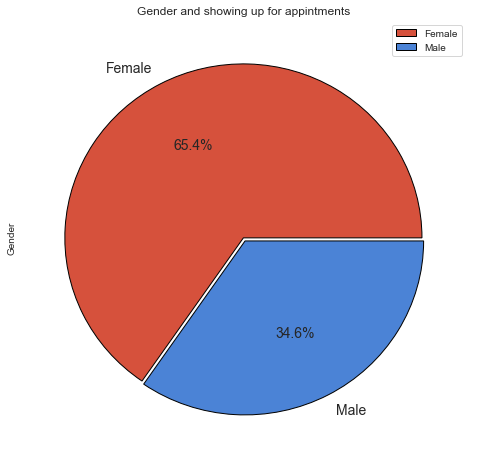

```python
appts_that_showed['Gender'].value_counts().plot(kind='pie',
    title = 'Gender and showing up for appintments', colors = ['#d6513c', '#4b83d6'],
    labels = ['Female','Male'], wedgeprops = {'edgecolor':'black'},
    autopct='%1.1f%%', legend = True, fontsize = (14),explode = [0, 0.02], figsize=(8, 8))
    #showing pie chart to see what role gender plays on
    # which patients show up for their appointments.
appts_that_showed.groupby(['Gender'])[['PatientId']].count()  #showing my numbers
```

What about for not showing up?

| Gender | PatientId |
| --- | --- |
| F | 57245 |
| M | 30962 |

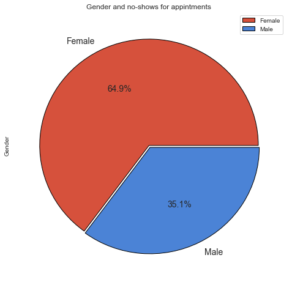

```python
did_not_show_up_appts['Gender'].value_counts().plot(kind='pie',
    title = 'Gender and no-shows for appintments', colors = ['#d6513c', '#4b83d6'],
    labels = ['Female','Male'], wedgeprops = {'edgecolor':'black'},
    autopct='%1.1f%%', legend = True, fontsize = (14),explode = [0, 0.02], figsize=(8, 8))
    #showing pie chart to see what role gender plays on
    # which patients show up for their appointments.
did_not_show_up_appts.groupby(['Gender'])[['PatientId']].count() #showing my numbers
```

It is interesting that by looking at both Gender pie charts, it suggests that most of the patients are female. However, it also does not seem that gender factors into whether a patient will show up for an appointment or not based on the data.

Next factor to look into is how handicap might affect showing up for appointments

| Handcap | PatientId |
| --- | --- |
| False | 21912 |
| True | 407 |

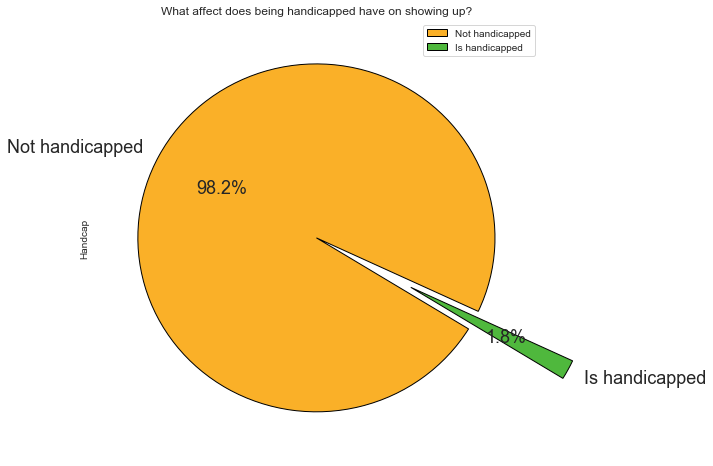

```python
#looking at the role handcap plays
appts_that_showed['Handcap'].value_counts().plot(kind='pie',
    title = 'What affect does being handicapped have on showing up?', colors = ['#fab028','#4fb83d' ],
    labels=['Not handicapped','Is handicapped'], startangle = -25,
    wedgeprops = {'edgecolor':'black'}, autopct='%1.1f%%', explode = [0, 0.6], legend = True, fontsize = (18), figsize=(8, 8))
appts_that_showed.groupby(['Handcap'])[['PatientId']].count()  #showing my numbers
```

And now looking at those that did not show up.

| Handcap | PatientId |
| --- | --- |
| False | 86373 |
| True | 1834 |

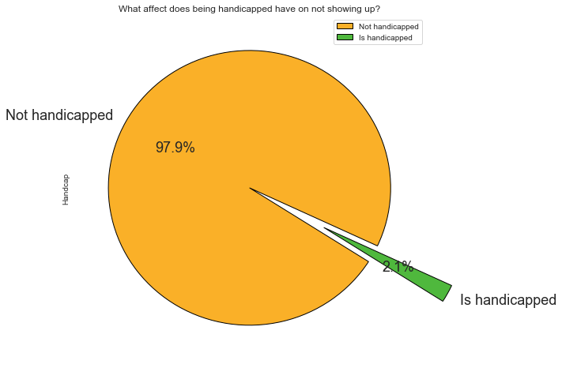

```python
#looking at the role handcap plays
did_not_show_up_appts['Handcap'].value_counts().plot(kind='pie',
    title = 'What affect does being handicapped have on not showing up?', colors = ['#fab028','#4fb83d' ],
    labels=['Not handicapped','Is handicapped'], startangle = -25,
    wedgeprops = {'edgecolor':'black'}, autopct='%1.1f%%', explode = [0, 0.6], legend = True, fontsize = (18),  figsize=(8, 8))
did_not_show_up_appts.groupby(['Handcap'])[['PatientId']].count()  #showing my numbers
```

It only shows a 0.3% diffrence here, which is not significant in this context.

Now to directly compare the percentages of those with a handicap, as per the date, that showed up or did not show up for their appointments.

```
No show  1834
Showed up  407
```

[figure not shown]

```python
# handicap and showing up
x = did_not_show_up_appts['Handcap'].value_counts()[True] #only grab values that are True
y = appts_that_showed['Handcap'].value_counts()[True]
sizes = pd.Series([x,y])
sizes.plot(kind='pie', labels = ['Did not show', 'Kept Appointment'],
    title = 'Diabetic affect on Showing up or No-Showing', colors = ['#fab028','#4fb83d'], startangle = -25,
    wedgeprops = {'edgecolor':'black'}, autopct='%1.1f%%', explode = [0, 0.1], legend = True, fontsize = (18),figsize=(8, 8))

print 'No show ', sizes.head().loc[0]  #showing my numbers for no shows
print 'Showed up ', sizes.head().loc[1] #and for those that showed up for their appointment
```

Now to look at alcoholism and its affect on showing up for patients.

| Alcoholism | PatientId |
| --- | --- |
| False | 21642 |
| True | 677 |

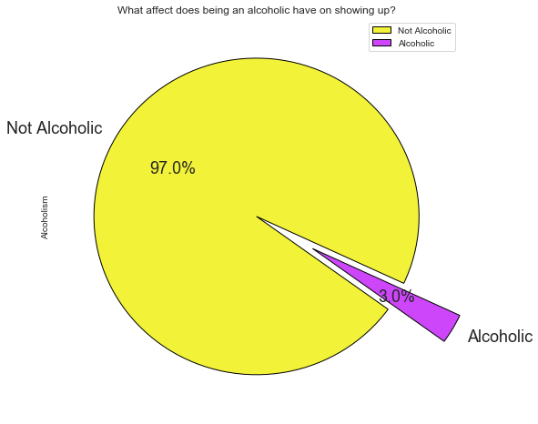

```python
# Alcoholism and showing up
appts_that_showed['Alcoholism'].value_counts().plot(kind='pie', labels = ['Not Alcoholic', 'Alcoholic'],
    title = 'What affect does being an alcoholic have on showing up?', colors = ['#f2f238', '#cd46fa' ], startangle = -25,
    wedgeprops = {'edgecolor':'black'}, autopct='%1.1f%%', explode = [0, 0.4], legend = True, fontsize = (18), figsize=(8, 8))
appts_that_showed.groupby(['Alcoholism'])[['PatientId']].count()
```

Now to look at those that did not keep their appointments.

| Alcoholism | PatientId |
| --- | --- |
| False | 85524 |
| True | 2683 |

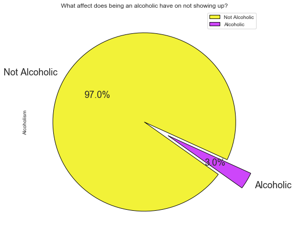

```python
# Alcoholism and showing up
did_not_show_up_appts['Alcoholism'].value_counts().plot(kind='pie', labels = ['Not Alcoholic', 'Alcoholic'],
    title = 'What affect does being an alcoholic have on not showing up?', colors = ['#f2f238', '#cd46fa' ], startangle = -25,
    wedgeprops = {'edgecolor':'black'}, autopct='%1.1f%%', explode = [0, 0.3], legend = True, fontsize = (18), figsize=(8, 8))
did_not_show_up_appts.groupby(['Alcoholism'])[['PatientId']].count()
```

Now to look directly at the alcoholics and if they showed up or not.

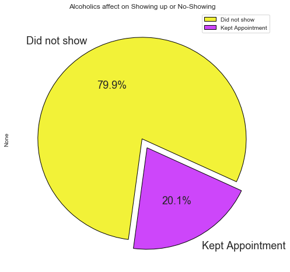

```python
# alcoholics and showing up
x = did_not_show_up_appts['Alcoholism'].value_counts()[True] #only grab values that are True
y = appts_that_showed['Alcoholism'].value_counts()[True]
sizes = pd.Series([x,y])
sizes.plot(kind='pie', labels = ['Did not show', 'Kept Appointment'],
    title = 'Alcoholics affect on Showing up or No-Showing', colors = ['#f2f238', '#cd46fa' ], startangle = -25,
    wedgeprops = {'edgecolor':'black'}, autopct='%1.1f%%', explode = [0, 0.1], legend = True, fontsize = (18),figsize=(8, 8))

print 'No show ', sizes.head().loc[0]
print 'Showed up ', sizes.head().loc[1]
```

[output not shown]

Now to look at diabetes.

| Diabetes | PatientId |
| --- | --- |
| False | 20889 |
| True | 1430 |

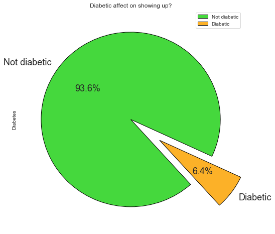

```python
# Diabetes and showing up
appts_that_showed['Diabetes'].value_counts().plot(kind='pie', labels = ['Not diabetic', 'Diabetic'],
    title = 'Diabetic affect on showing up?', colors = ['#45d83d', '#fcb128' ], startangle = -25,
    wedgeprops = {'edgecolor':'black'}, autopct='%1.1f%%', explode = [0, 0.4], legend = True, fontsize = (18), figsize=(8, 8))
appts_that_showed.groupby(['Diabetes'])[['PatientId']].count()  #showing my numbers
```

And not to look at those that did not keep their appointments.

| Diabetes | PatientId |
| --- | --- |
| False | 81694 |
| True | 6513 |

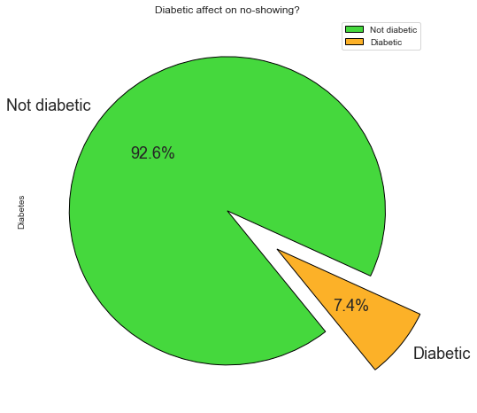

```python
# Diabetes and showing up
excd = did_not_show_up_appts['Diabetes'].value_counts()
excd.plot(kind='pie', labels = ['Not diabetic', 'Diabetic'],
    title = 'Diabetic affect on no-showing?', colors = ['#45d83d', '#fcb128' ], startangle = -25,
    wedgeprops = {'edgecolor':'black'}, autopct='%1.1f%%', explode = [0, 0.4], legend = True, fontsize = (18),figsize=(8, 8))
did_not_show_up_appts.groupby(['Diabetes'])[['PatientId']].count()
```

Now to look directly at the percentage of diabetics that did or did not show up for their appointment.

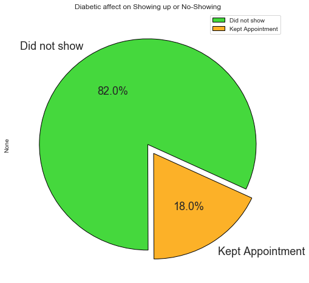

```python
# Diabetes and showing up
x = did_not_show_up_appts['Diabetes'].value_counts()[True] #only grab True values aka people that are diabetic
y = appts_that_showed['Diabetes'].value_counts()[True]
sizes = pd.Series([x,y])
sizes.plot(kind='pie', labels = ['Did not show', 'Kept Appointment'],
    title = 'Diabetic affect on Showing up or No-Showing', colors = ['#45d83d', '#fcb128' ], startangle = -25,
    wedgeprops = {'edgecolor':'black'}, autopct='%1.1f%%', explode = [0, 0.1], legend = True, fontsize = (18),figsize=(8, 8))

print 'No show ', sizes.head().loc[0]
print 'Showed up ', sizes.head().loc[1]
```

[output not shown]

And not to look at how hipertension affects keeping appointments.

| Hipertension | PatientId |
| --- | --- |
| False | 18547 |
| True | 3772 |

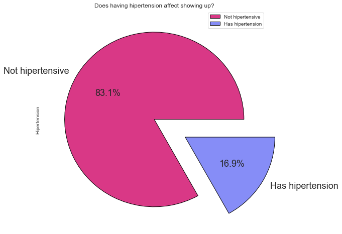

```python
# Hipertension and showing up
appts_that_showed['Hipertension'].value_counts().plot(kind='pie', labels = ['Not hipertensive', 'Has hipertension'],
    title = 'Does having hipertension affect showing up?', colors = ['#d93886', '#868df7' ],
    wedgeprops = {'edgecolor':'black'}, autopct='%1.1f%%', explode = [0, 0.4], legend = True, fontsize = (18), figsize=(8, 8))
appts_that_showed.groupby(['Hipertension'])[['PatientId']].count()
```

Looking at those with hipertension that did not keep their appointments.

| Hipertension | PatientId |
| --- | --- |
| False | 70178 |
| True | 18029 |

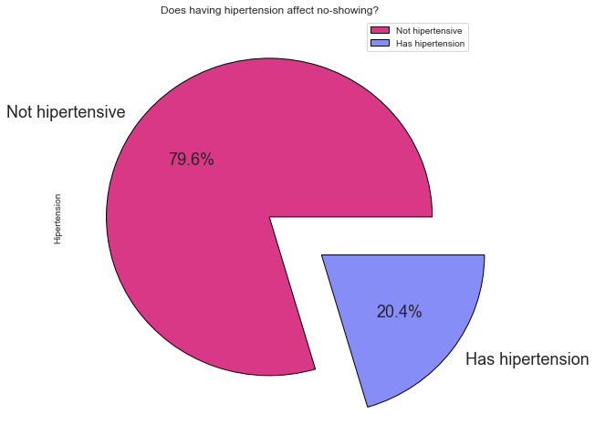

```python
# Hipertension and showing up
did_not_show_up_appts['Hipertension'].value_counts().plot(kind='pie', labels = ['Not hipertensive', 'Has hipertension'],
    title = 'Does having hipertension affect no-showing?', colors = ['#d93886', '#868df7' ],
    wedgeprops = {'edgecolor':'black'}, autopct='%1.1f%%', explode = [0, 0.4], legend = True, fontsize = (18), figsize=(8, 8))
did_not_show_up_appts.groupby(['Hipertension'])[['PatientId']].count()
```

And directly comparing all those with hipertension and whether they kept their appointments.

```
No show  18029
Showed up  3772
```

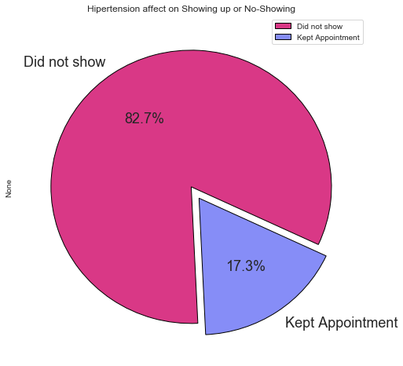

```python
# Hipertension and showing up
x = did_not_show_up_appts['Hipertension'].value_counts()[True]
y = appts_that_showed['Hipertension'].value_counts()[True]
sizes = pd.Series([x,y])
sizes.plot(kind='pie', labels = ['Did not show', 'Kept Appointment'],
    title = 'Hipertension affect on Showing up or No-Showing', colors = ['#d93886', '#868df7' ], startangle = -25,
    wedgeprops = {'edgecolor':'black'}, autopct='%1.1f%%', explode = [0, 0.1], legend = True, fontsize = (18),figsize=(8, 8))

print 'No show ', sizes.head().loc[0]
print 'Showed up ', sizes.head().loc[1]
```

Next will be looking at the affect of having a scholarship.

| Scholarship | PatientId |
| --- | --- |
| False | 19741 |
| True | 2578 |

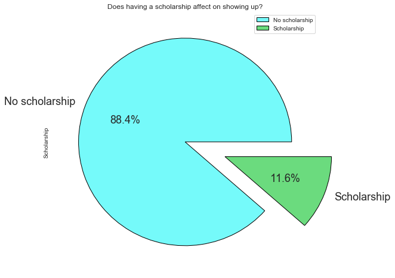

```python
# Scholarship and showing up
appts_that_showed['Scholarship'].value_counts().plot(kind='pie',  labels = ['No scholarship', 'Scholarship'],
    title = 'Does having a scholarship affect on showing up?', colors = ['#75fafa', '#6bdb7e' ],
    wedgeprops = {'edgecolor':'black'}, autopct='%1.1f%%', explode = [0, 0.4], legend = True, fontsize = (18), figsize=(8, 8))
appts_that_showed.groupby(['Scholarship'])[['PatientId']].count()
```

Now to look at those that did not keep their appointment.

| Scholarship | PatientId |
| --- | --- |
| False | 79924 |
| True | 8283 |

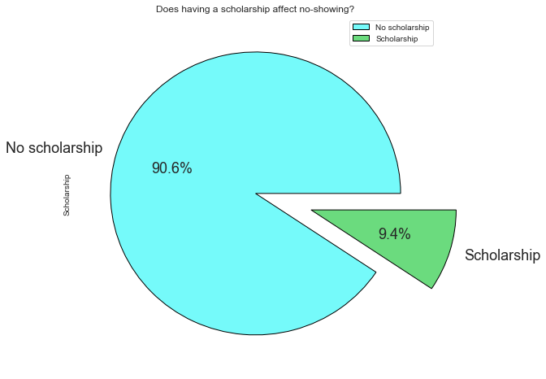

```python
# Scholarship and showing up
did_not_show_up_appts['Scholarship'].value_counts().plot(kind='pie',  labels = ['No scholarship', 'Scholarship'],
    title = 'Does having a scholarship affect no-showing?', colors = ['#75fafa', '#6bdb7e' ],
    wedgeprops = {'edgecolor':'black'}, autopct='%1.1f%%', explode = [0, 0.4], legend = True, fontsize = (18), figsize=(8, 8))
did_not_show_up_appts.groupby(['Scholarship'])[['PatientId']].count()
```

Directly comparing only those with scholarships and whether they kept their appointment or not.

```
No show  8283
Showed up  2578
```

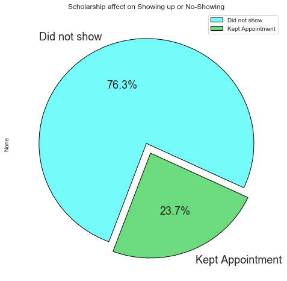

```python
# Scholarship and showing up
x = did_not_show_up_appts['Scholarship'].value_counts()[True]
y = appts_that_showed['Scholarship'].value_counts()[True]
sizes = pd.Series([x,y])
sizes.plot(kind='pie', labels = ['Did not show', 'Kept Appointment'],
    title = 'Scholarship affect on Showing up or No-Showing', colors = ['#75fafa', '#6bdb7e' ], startangle = -25,
    wedgeprops = {'edgecolor':'black'}, autopct='%1.1f%%', explode = [0, 0.1], legend = True, fontsize = (18),figsize=(8, 8))
print 'No show ', sizes.head().loc[0]
print 'Showed up ', sizes.head().loc[1]
```

Next should be an interesting catigory; looking at the affect SMS reminders being sent has on patients keeping their appointments.

| SMS_received | PatientId |
| --- | --- |
| False | 12535 |
| True | 9784 |

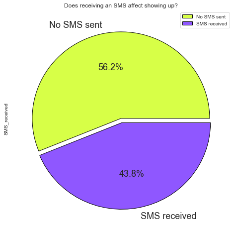

```python
# SMS_recieved and showing up
appts_that_showed['SMS_received'].value_counts().plot(kind='pie',  labels = ['No SMS sent', 'SMS received'],
    title = 'Does receiving an SMS affect showing up?', colors = ['#d7ff47', '#8f57ff' ],
    wedgeprops = {'edgecolor':'black'}, autopct='%1.1f%%',explode = [0, 0.05], legend = True, fontsize = (18), figsize=(8, 8))
appts_that_showed.groupby(['SMS_received'])[['PatientId']].count()
```

And now looking at those that did not keep the appointment.

| SMS_received | PatientId |
| --- | --- |
| False | 62509 |
| True | 25698 |

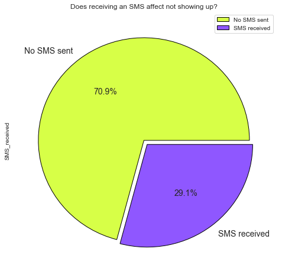

```python
# SMS_recieved and showing up
did_not_show_up_appts['SMS_received'].value_counts().plot(kind='pie',  labels = ['No SMS sent', 'SMS received'],
    title = 'Does receiving an SMS affect not showing up?', colors = ['#d7ff47', '#8f57ff' ],
    wedgeprops = {'edgecolor':'black'}, autopct='%1.1f%%',explode = [0, 0.05], legend = True, fontsize = (14), figsize=(8, 8))
did_not_show_up_appts.groupby(['SMS_received'])[['PatientId']].count()
```

Directly comparing only those that did receive a SMS reminder and whether or not they kept the appointment is next.

```
No show  25698
Showed up  9784
```

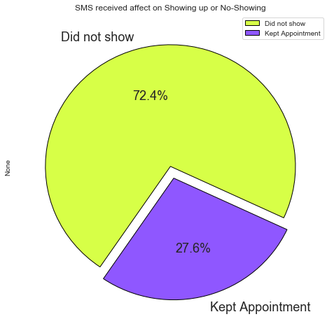

```python
# SMS_received and showing up
x = did_not_show_up_appts['SMS_received'].value_counts()[True] #grabs only true values
y = appts_that_showed['SMS_received'].value_counts()[True]
sizes = pd.Series([x,y])
sizes.plot(kind='pie', labels = ['Did not show', 'Kept Appointment'],
    title = 'SMS received affect on Showing up or No-Showing', colors = ['#d7ff47', '#8f57ff' ], startangle = -25,
    wedgeprops = {'edgecolor':'black'}, autopct='%1.1f%%', explode = [0, 0.1], legend = True, fontsize = (18),figsize=(8, 8))

print 'No show ', sizes.head().loc[0]
print 'Showed up ', sizes.head().loc[1]
```

Now to look at the effect of where the patient lives might have on keeping appointments. These will each have a threshold value assigned to them so that the more relavant data is easier to observe.

```
count              22319
unique                80
top       JARDIM CAMBURI
freq                1465
Name: Neighbourhood, dtype: object
```

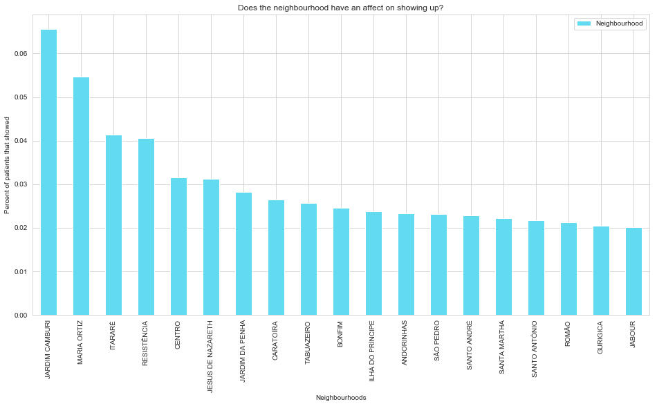

```python
s = appts_that_showed['Neighbourhood'].value_counts(normalize = True) #using this to count how many instances for each type of value.
threshold = .02 #the cut off value point
mask = s > threshold #logic, creating a True False Series that I can use as a mask
tail_prod = s.loc[~mask].sum() #this gives me a sum of the (~ tidle is inverse) inverse mask so I can get the values below the threshold
s = s.loc[mask] #setting s to now only hold the series related to the mask
#s['Other'] = tail_prod
plt.xlabel('Neighbourhoods')
plt.ylabel('Percent of patients that showed')
s.plot(kind='bar', title = 'Does the neighbourhood have an affect on showing up?', legend = True,  color=['#62daf0'],figsize=(16,8))
appts_that_showed['Neighbourhood'].describe()  #showing the numbers
#Using this code, I am looking to drop any count of instances that happened less than 600 times,
#as it just isnt significan enough to count. and looks better organized this way.
```

The neighbourhood location of a patient does play a factor in whether they will keep an appointment or not it seems. It does not seem to be a major factor however.

Now to look at locations for those that do not show up for appointments.

```
count              88207
unique                80
top       JARDIM CAMBURI
freq                6252
Name: Neighbourhood, dtype: object
```

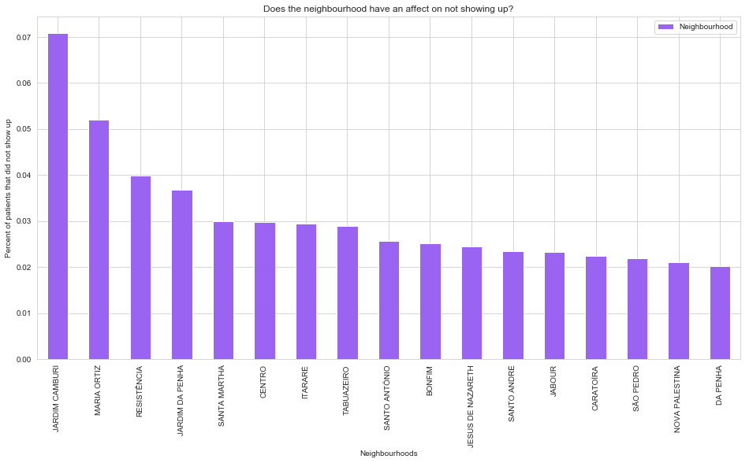

```python
s = did_not_show_up_appts['Neighbourhood'].value_counts(normalize = True) #using this to count how many instances for each type of value.
threshold = .02 #the cut off value point
mask = s > threshold #logic, creating a True False Series that I can use as a mask
tail_prod = s.loc[~mask].sum() #this gives me a sum of the (~ tidle is inverse) inverse mask so I can get the values below the threshold
s = s.loc[mask] #setting s to now only hold the series related to the mask
plt.xlabel('Neighbourhoods')
plt.ylabel('Percent of patients that did not show up')
s.plot(kind='bar', title = 'Does the neighbourhood have an affect on not showing up?', legend = True, color = ['#9a63f2'],figsize=(16,8))
did_not_show_up_appts['Neighbourhood'].describe()
#Using this code, I am looking to drop any count of instances that happened less than 600 times,
#as it just isnt significan enough to count. and looks better organized this way.
```

Similar findings as were seen for those that did keep their appointments are observed.

Looking at how age affects keeping appointments next.

```
count              22,319.00
mean                   34.32
std                    21.97
min                     0.00
25%                    16.00
50%                    33.00
75%                    51.00
max                   115.00
Name: Age, dtype: float64
```

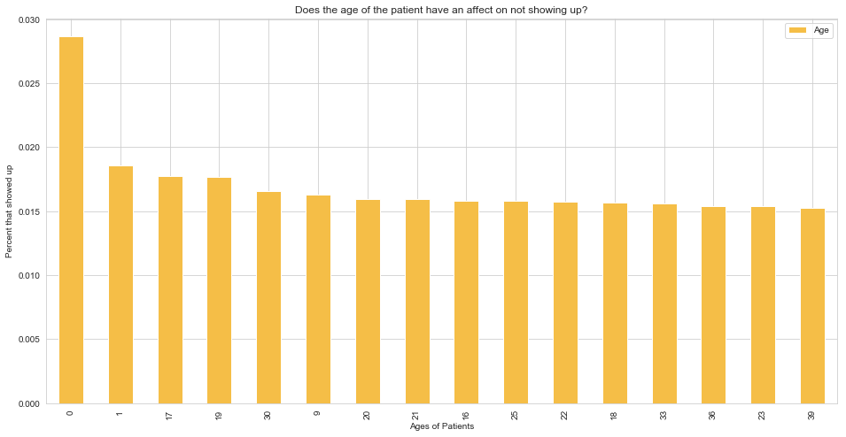

```python
b = appts_that_showed['Age'].value_counts(normalize = True) #counting each values frequency
b_thresold = .015
b_mask = b > b_thresold #mask where values are greater than the thresold.
b = b.loc[b_mask] #pull only those values that the mask allows.
plt.xlabel('Ages of Patients')
plt.ylabel('Percent that showed up')
b.plot(kind='bar',title = 'Does the age of the patient have an affect on not showing up?', legend = True, color = ['#f5be47'], figsize=(16,8)) #showingAge
appts_that_showed['Age'].describe()  #showing the numbers for the data
```

## Conclusion

In summary, although there are still limitations in the data (for example, in the category of 'No-Show' I take it to mean that a person did not show up for their appointment when the value is "True" but this could be in error.) and also limitations in the analysis. However, based on observations, some insights can be gained that can be useful.

From looking over the data, what is observed is a few interesting finds that might prove useful to a buisness and helping patients keep their appointments. These are as follows:

-A majority of all patients are female, with both sexes keeping their appointments approximately the same amount of times.

-Neighbourhood does not have a signigicant affect on clients keeping their appointments.

These are the biggest factors that impact whether a patient will show up for their appointment.

Back up to Table of Contents